# Rolling Average

# Seven-day Rolling Average

- Use [zoo](https://cran.r-project.org/web/packages/zoo/index.html) package to calculate rolling average

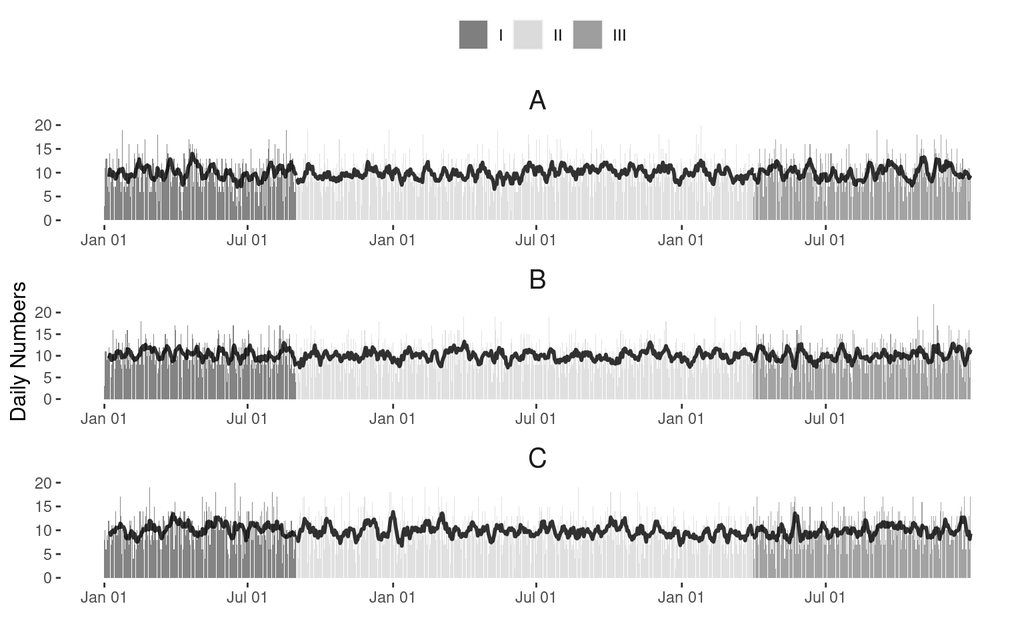

```r
dates <- seq(
    from = as.Date("2018-01-01", format = "%Y-%m-%d")
  , to = as.Date("2020-12-31", format = "%Y-%m-%d")
  , by = 1
)


dt <- data.table(
    date = rep(dates, 3)
  , site = rep(c("A", "B", "C"), each = length(dates))
  , daily_volume = rpois(n = length(dates) * 3, lambda = 10)
)

library(zoo)
dt <- dt[order(site, date)
         ][, rolling_avg_7days := rollmean(daily_volume, k = 7, na.pad = TRUE, align = "right"), by = .(site)]


dt <- dt[, period := case_when(
               date <= as.Date("2018-08-31", format = "%Y-%m-%d") ~ "I"
             , date > as.Date("2020-03-31", format = "%Y-%m-%d") ~ "III"
               , TRUE ~ "II"
           )]


clrs <- c(
  "#333333"
 ,"#cccccc"
, "#666666"
)


brks <- as.Date(c("2018-01-01", "2018-07-01", "2019-01-01", "2019-07-01", "2020-01-01", "2020-07-01")
              , format = "%Y-%m-%d")

p1 <- ggplot(dt, aes(x = date, y = daily_volume, fill = period)) +
    geom_bar(stat = "identity", alpha = 0.6) +
    ## geom_line(data = sm2, aes(x = date_procedure, y = mv7, group = period, color = period), size = 1, alpha = 1) +
    geom_line(data = dt, aes(x = date, y = rolling_avg_7days), size = 1, alpha = 0.8) +
    scale_x_continuous(breaks=brks, labels = format(brks, "%b %d")) +
    scale_fill_manual(values = clrs) +
    ## scale_color_manual(values = clrs) +
    theme(panel.background = element_rect(fill = "transparent")
        , plot.background = element_rect(fill = "transparent", color = NA)
        , panel.grid.major = element_blank()
        , panel.grid.minor = element_blank()
        , axis.title.y = element_text(size = 12)
          ## , legend.background = element_rect(fill = "transparent")
          ## , legend.box.background = element_rect(fill = "transparent")
        , strip.background =element_rect(fill="transparent")
        , strip.text.x = element_text(size = 15)
        , legend.position = 'top'
        , legend.title = element_blank()
          ## , plot.margin=unit(c(1,2,1,2),"cm")
          ) +
    ## theme(axis.text.x = element_text(angle = 45)) +
    facet_wrap(~ site, nrow = 3, scales = "free") +
    xlab("") +
    ylab("Daily Numbers")


## png(filename = "p1.png", width = 12, height = 6, units = "in", res = 300)
p1
```

```r
## dev.off()
```

R version 4.2.0 (2022-04-22) Platform: x86_64-pc-linux-gnu (64-bit) Running under: Ubuntu 20.04.3 LTS

Matrix products: default BLAS: /usr/lib/x86_64-linux-gnu/blas/libblas.so.3.9.0 LAPACK: /usr/lib/x86_64-linux-gnu/lapack/liblapack.so.3.9.0

attached base packages: [1] stats graphics grDevices utils datasets methods base